# Análisis Multivariado - Clase 3

## Variables aleatorias

## Motivación

```
##   Hidratación Alimentación Pantallas     Sueño      Test  Puntaje
## 1    94.69166    102.19951  91.10375  98.77666 Cognitivo 214.7968
## 2    97.82053    102.75819 105.44395 117.37921 Cognitivo 224.4305
## 3   101.56877    100.60776 106.35822 106.98909    Físico 203.7226
## 4   101.93731    104.98654  90.82423  93.58370    Físico 191.1300
## 5    95.64230     97.20868  85.99073 104.62088 Cognitivo 236.1101
## 6    97.10112    101.68953 111.76633 116.04422 Cognitivo 208.3873
```

## Variables aleatorias

**Variable aleatoria:** antes de tomar la muestra, cada variable puede tomar varios valores. Como no se pueden predecir sus resultados, son aleatorias.

- \(p\): Cantidad de variables
- \(n\): Cantidad de observaciones
- \(X_{i,j}\): \(i\)-ésima observación de la \(j\)-ésima variable.

Podemos juntar todas estas variables en una matriz de variables \(\mathbf{X} \in \mathbb{R}^{n\times p}\): \[\small \mathbf{X}=\begin{pmatrix} X_{1,1}& X_{1,2} & \cdots & X_{1,p}\\ X_{2,1}& X_{2,2} & \cdots & X_{2,p}\\ \vdots& \vdots & \ddots & \vdots\\ X_{n,1}& X_{n,2} & \cdots & X_{n,p}\\ \end{pmatrix} \]

## Datos

Una vez tomada la muestra, las variables pasan a tomar valores **fijos**. Dejan de ser variables y pasan a ser **datos**, por eso lo notamos con letras minúsculas:

- \(p\): Cantidad de variables
- \(n\): Cantidad de observaciones
- \(x_{i,j}\): \(i\)-ésima observación de la \(j\)-ésima variable.

Podemos juntar todas estas variables en una matriz de datos \(\mathbf{x} \in \mathbb{R}^{n\times p}\): \[\small \mathbf{x}=\begin{pmatrix} x_{1,1}& x_{1,2} & \cdots & x_{1,p}\\ x_{2,1}& x_{2,2} & \cdots & x_{2,p}\\ \vdots& \vdots & \ddots & \vdots\\ x_{n,1}& x_{n,2} & \cdots & x_{n,p}\\ \end{pmatrix} \]

## Distribuciones

Cada variable \(X_{i,j}\) obedece a una distribución de frecuencias \(F_{i,j}\), ya que no todos los valores que pueden tomar son igual de frecuentes.

En general, consideramos que todas las observaciones de una misma variable \(X_{i,j}\) siguen la misma distribución \(F_{j}\):

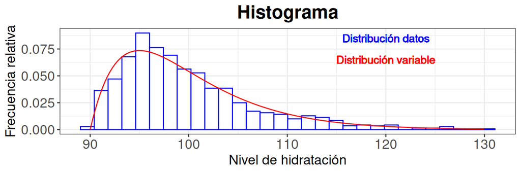

## Media

Para una variable aleatoria \(X_{i,j}\), se denomina la esperanza como al valor que promedia todas las frecuencias de los valores. \[\scriptsize \mu_{j}=E(X_{i,j}) \]

Una vez que obtenemos un conjunto de datos \(x_{i,j}\), el valor que estima esta esperanza es la media: \[\scriptsize \overline{x}_j=\dfrac{\sum_{i=1}^n x_{i,j}}{n} \]

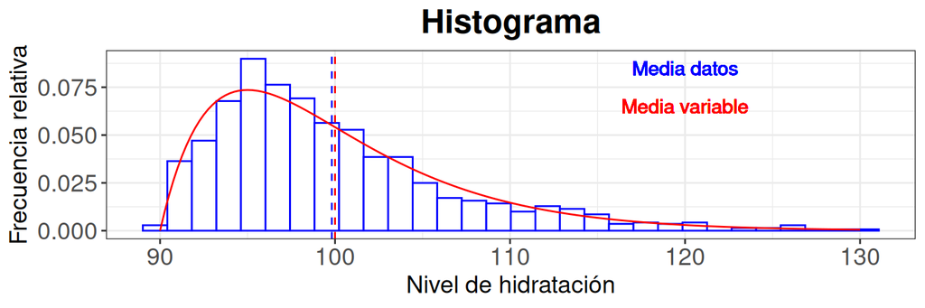

## Varianza y desvío

La varianza permite ver cuánto tiende una variable a dispersarse de su esperanza. Se llama desvío estándard a la raíz de la varianza: \[\sigma^2_{j}=V(X_{i,j})=E([X_{i,j}-\mu_{i,j}]^2)\Rightarrow \sigma_j=\sigma(X_{i,j})=\sqrt{V(X_{i,j})} \]

Una vez obtenidos los datos, la varianza y el desvío se estiman con sus valores muestrales: \[s^2_{j}=\sum_{i=1}^n \dfrac{(x_{i,j}-\overline{x}_j)^2}{n-1}\Rightarrow s_{j}=\sqrt{ \sum_{i=1}^n \dfrac{(x_{i,j}-\overline{x}_j)^2}{n-1} }\]

## Covarianza

Una medida de asociación lineal entre dos variables es la covarianza: \[ \text{Cov}(X_{i,j};X_{i,k})=\sigma_{j,k}=E([X_{i,j}-\mu_j]\cdot [X_{i,k}-\mu_k]) \]

El problema es que el valor de la covarianza no es tan interpretable, ya que depende de las unidades de ambas variables. Por ejemplo, si \(X_{i,j}\) está medido en metros y \(X_{i,k}\) está medido en segundos, \(\text{Cov}(X_{i,j};X_{i,k})\) está medido en metros por segundo.

Se estima con la siguiente expresión (Covarianza de Pearson): \[s_{j,k}=\sum_{i=1}^n\dfrac{ (x_{i,j}-\overline{x}_j)\cdot (x_{i,k}-\overline{x}_k)}{n-1} \]

## Propiedades

**Simetría** La covarianza es simétrica. \[\text{Cov}(X_{i,j};X_{i,k})=E([X_{i,j}-\mu_j]\cdot [X_{i,k}-\mu_k])=\] \[=E([X_{i,k}-\mu_k]\cdot [X_{i,j}-\mu_j])=\text{Cov}(X_{i,k};X_{i,j})\]

**Covarianza y Varianza:** La covarianza de una variable con sí misma da como resultado la varianza \[\text{Cov}(X_{i,j};X_{i,j})=E([X_{i,j}-\mu_j]\cdot [X_{i,j}-\mu_j])=\] \[= E([X_{i,j}-\mu_j]^2)=V(X_{i,j})\]

## Correlación

Ante la dificultad de interpretar la covarianza, se suele utilizar la correlación: \[ \rho(X_{i,j};X_{i,k})=\dfrac{\text{Cov}(X_{i,j};X_{i,k})}{\sigma(X_{i,j})\cdot \sigma(X_{i,k})} \]

Se estima mediante la siguiente fórmula (Correlación de Pearson): \[r_{j,k}=\dfrac{\sum_{i=1}^n (x_{i,j}-\overline{x}_j)\cdot (x_{i,k}-\overline{x}_k)}{\sqrt{\sum_{i=1}^n (x_{i,j}-\overline{x}_j)^2}\cdot \sqrt{\sum_{i=1}^n (x_{i,k}-\overline{x}_k)^2}} \]

## Interpretación

Este valor se encuentra entre -1 y 1 y mide la asociación lineal entre ambas variables.

- \(\rho\approx 1\): la asociación lineal es fuerte y creciente.
- \(\rho\approx -1\): la asociación lineal es fuerte y decreciente.
- \(\rho\approx 0\): asociación lineal muy débil o inexistente.
- **Simetría:** \(\rho(X_{i,j};X_{i,k})=\rho(X_{i,k};X_{i,j})\)
- **Propiedad:** \(\rho(X_{i,j};X_{i,j})=1\)

## Vectores Aleatorios

## Vectores Aleatorios

Cuando analizamos varias variables aleatorias al mismo tiempo, se dice que tenemos un **vector aleatorio**: \[\mathbf{X}_i=(X_{i,1};X_{i,2};\cdots;X_{i,p})\in \mathbb{R}^p\]

Es decir, es el vector de variables de la observación \(i\) antes de tomar la muestra. De todas formas, se suele asumir que todos los vectores aleatorios \(\mathbf{X}_i\) siguen una misma distribución de frecuencias \(F_{\mathbf{X}}\). La diferencia ahora es que esta distribución cuenta las combinaciones de las variables, por eso se llama distribución conjunta.

Una vez observados los datos, se obtienen los vectores de datos \(\mathbf{x}_i\): \[\mathbf{x}_i=(x_{i,1};x_{i,2};\cdots;x_{i,p})\in \mathbb{R}^p\]

## Comparación distribuciones

En el siguiente gráfico comparamos la distribución teórica de las variables Hidratación y Alimentación, junto con las frecuencias de los valores observados.

[interactive chart not shown]

## Media de un vector aleatorio

El concepto de esperanza cambia para un vector aleatorio ya que no hay una idea de “centro” para un vector. De todos modos, este concepto es válido coordenada a coordenada, y es justamente el modo en el que se calcula el vector de medias: \[\scriptsize E(\mathbf{X}_i)=(E(X_{i,1});E(X_{i,2});\cdots;E(X_{i,p}))=(\mu_1,\mu_2,\cdots,\mu_p)=\vec{\mu} \]

Una vez observados los datos, esta media se estima con el vector de promedios: \[\overline{x}=(\overline{x}_1;\overline{x}_2;\cdots;\overline{x}_p) \]

## Ejemplo

Por ejemplo, para las variables de hidratación y alimentación de la base simulada obtenemos el siguiente vector de medias (simbolizado en color rojo):

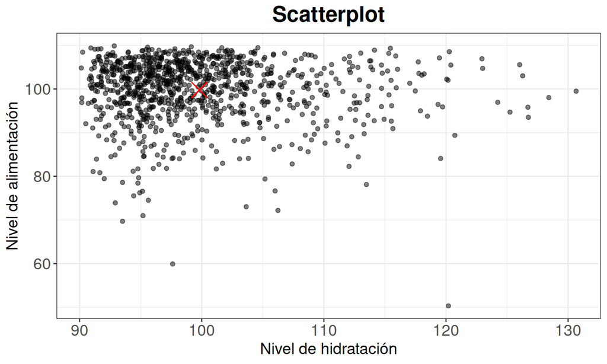

## Matriz de covarianza

Una de las mayores diferencias entre variables aleatorias y vectores aleatorios es que los vectores aleatorios tienen asociadas una matriz de covarianza, donde se visualizan al mismo tiempo las covarianzas de todos los pares de variables.

Es decir: \[\small \text{Cov}(\mathbf{X})= \begin{pmatrix} \text{Cov}(X_{i,1};X_{i,1}) & \text{Cov}(X_{i,1};X_{i,2})& \cdots & \text{Cov}(X_{i,1};X_{i,p})\\ \text{Cov}(X_{2,1};X_{i,1}) & \text{Cov}(X_{i,2};X_{i,2})& \cdots & \text{Cov}(X_{i,2};X_{i,p})\\ \vdots & \vdots& \ddots & \vdots\\ \text{Cov}(X_{i,p};X_{i,1}) & \text{Cov}(X_{i,p};X_{i,2})& \cdots & \text{Cov}(X_{i,p};X_{i,p})\\ \end{pmatrix} \]

## Matriz de covarianza

Notar que en la diagonal se ubican las varianzas, al tratarse de la misma variable:

\[\scriptsize \Sigma= \text{Cov}(\mathbf{X})= \begin{pmatrix} \text{Var}(X_{i,1}) & \text{Cov}(X_{i,1};X_{i,2})& \cdots & \text{Cov}(X_{i,1};X_{i,p})\\ \text{Cov}(X_{2,1};X_{i,1}) & \text{Var}(X_{i,2})& \cdots & \text{Cov}(X_{i,2};X_{i,p})\\ \vdots & \vdots& \ddots & \vdots\\ \text{Cov}(X_{i,p};X_{i,1}) & \text{Cov}(X_{i,p};X_{i,2})& \cdots & \text{Var}(X_{i,p})\\ \end{pmatrix} \]

Utilizando la notación anterior: \[\scriptsize \text{Cov}(\mathbf{X})= \begin{pmatrix} \sigma_1^2 & \sigma_{1,2}& \cdots & \sigma_{1,p}\\ \sigma_{2,1} & \sigma_2^2& \cdots & \sigma_{2,p}\\ \vdots & \vdots& \ddots & \vdots\\ \sigma_{p,1} & \sigma_{p,2}& \cdots & \sigma_p^2\\ \end{pmatrix} \]

## Estimación

La matriz de covarianza se puede estimar con las covarianzas muestrales: \[\small\widehat{\Sigma}= \begin{pmatrix} s_1^2 & s_{1,2}& \cdots & s_{1,p}\\ s_{2,1} & s_2^2& \cdots & s_{2,p}\\ \vdots & \vdots& \ddots & \vdots\\ s_{p,1} & s_{p,2}& \cdots & s_p^2\\ \end{pmatrix} \]

## Matriz de correlación

Del mismo modo, se puede calcular la matriz de correlación

\[\scriptsize \mathbf{R}=\text{Cor}(\mathbf{X})= \begin{pmatrix} \text{Cor}(X_{i,1};X_{i,1}) & \text{Cor}(X_{i,1};X_{i,2})& \cdots & \text{Cor}(X_{i,1};X_{i,p})\\ \text{Cor}(X_{2,1};X_{i,1}) & \text{Cor}(X_{i,2};X_{i,2})& \cdots & \text{Cor}(X_{i,2};X_{i,p})\\ \vdots & \vdots& \ddots & \vdots\\ \text{Cor}(X_{i,p};X_{i,1}) & \text{Cor}(X_{i,p};X_{i,2})& \cdots & \text{Cor}(X_{i,p};X_{i,p})\\ \end{pmatrix} \]

Utilizando la notación anterior y como la correlación entre una variable y sí misma siempre da 1: \[\scriptsize \mathbf{R}= \text{Cor}(\mathbf{X})= \begin{pmatrix} 1 & \rho_{1,2}& \cdots & \rho_{1,p}\\ \rho_{2,1} & 1& \cdots & \rho_{2,p}\\ \vdots & \vdots& \ddots & \vdots\\ \rho_{p,1} & \rho_{p,2}& \cdots & 1\\ \end{pmatrix} \]

## Estimación

La matriz de correlación se puede estimar con sus correlaciones muestrales: \[\small\widehat{\mathbf{R}}= \begin{pmatrix} 1 & r_{1,2}& \cdots & r_{1,p}\\ r_{2,1} & s_2^2& \cdots & r_{2,p}\\ \vdots & \vdots& \ddots & \vdots\\ r_{p,1} & r_{p,2}& \cdots & r_p^2\\ \end{pmatrix} \]

## Propiedades

- Ambas matrices son **simétricas**
- Ambas matrices son semidefinidas positivas: \[\vec{v}\times \Sigma \times \vec{v}^T\ge 0, \vec{v}\times \mathbf{R} \times \vec{v}^T\ge 0,\forall \vec{v}\]
- Ambas matrices tienen **todos** sus **autovalores positivos**.
- Otra forma de escribir la matriz de covarianza es: \[\Sigma= E\left[(\mathbf{X}_i-\vec{\mu})^T \times (\mathbf{X}_i-\vec{\mu}) \right] =\] \[= E\left[\begin{pmatrix}X_{i,1}-\mu_1 \\ X_{i,2}-\mu_2 \\ \vdots \\ X_{i,p}-\mu_p \end{pmatrix} \times \begin{pmatrix}X_{i,1}-\mu_1 & X_{i,2}-\mu_2 & \cdots & X_{i,p}-\mu_p \end{pmatrix} \right] =\Sigma \]

## Ejemplo

Por ejemplo, estimamos la matriz de covarianza para los datos simulados. Vale aclarar que el cálculo de covarianza sólo tiene sentido para variables **cuantitativas**, por eso removemos la variable categórica de los datos para realizar el cálculo.

```r
round(cov(DatSim[,-5]),3)
```

```
##              Hidratación Alimentación Pantallas   Sueño  Puntaje
## Hidratación       46.161       -2.014     2.973   3.055   69.500
## Alimentación      -2.014       50.580     3.475  -0.031  -81.401
## Pantallas          2.973        3.475   125.630   6.657 -113.595
## Sueño              3.055       -0.031     6.657 139.878  121.108
## Puntaje           69.500      -81.401  -113.595 121.108  900.159
```

## Ejemplo

Del mismo modo, podemos estimar la matriz de correlación

```r
round(cor(DatSim[,-5]),3)
```

```
##              Hidratación Alimentación Pantallas Sueño Puntaje
## Hidratación        1.000       -0.042     0.039 0.038   0.341
## Alimentación      -0.042        1.000     0.044 0.000  -0.381
## Pantallas          0.039        0.044     1.000 0.050  -0.338
## Sueño              0.038        0.000     0.050 1.000   0.341
## Puntaje            0.341       -0.381    -0.338 0.341   1.000
```

## Ejemplo (sólo test físico)

```r
round(cor(DatSim[IndF,-5]),3)
```

```
##              Hidratación Alimentación Pantallas  Sueño Puntaje
## Hidratación        1.000       -0.082     0.025  0.025   0.736
## Alimentación      -0.082        1.000     0.023  0.082  -0.734
## Pantallas          0.025        0.023     1.000  0.033   0.000
## Sueño              0.025        0.082     0.033  1.000  -0.039
## Puntaje            0.736       -0.734     0.000 -0.039   1.000
```

## Ejemplo (sólo test cognitivo)

```r
round(cor(DatSim[IndC,-5]),3)
```

```
##              Hidratación Alimentación Pantallas  Sueño Puntaje
## Hidratación        1.000       -0.009     0.052  0.050   0.001
## Alimentación      -0.009        1.000     0.064 -0.073  -0.101
## Pantallas          0.052        0.064     1.000  0.069  -0.660
## Sueño              0.050       -0.073     0.069  1.000   0.703
## Puntaje            0.001       -0.101    -0.660  0.703   1.000
```

## Falsas relaciones lineales (Test Físico)

```r
round(cor(DatSim[IndF,1]+DatSim[IndF,2],DatSim[IndF,6]),3)
```

```
## [1] 0.001
```

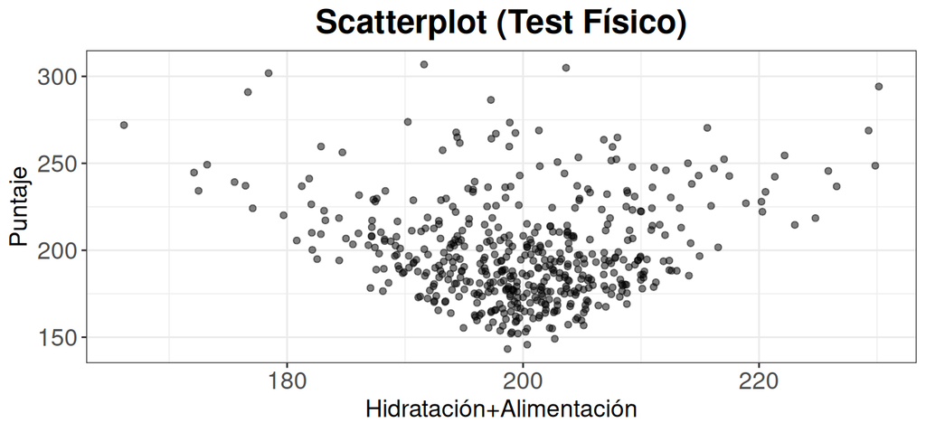

## Verdaderas relaciones lineales (Test Físico)

```r
round(cor(DatSim[IndF,1]-DatSim[IndF,2],DatSim[IndF,6]),3)
```

```
## [1] 0.999
```

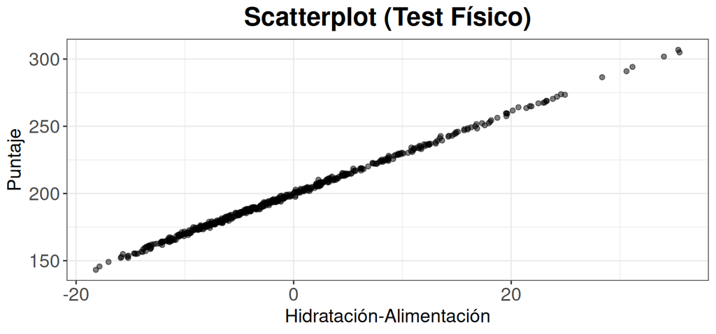

## Verdaderas relaciones lineales (Test Físico)

```r
round(cor(-DatSim[IndF,1]+DatSim[IndF,2],DatSim[IndF,6]),3)
```

```
## [1] -0.999
```

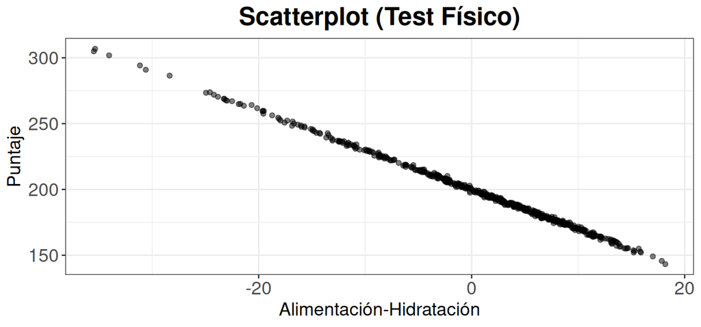

## Falsas relaciones lineales (Test Físico)

```r
round(cor(DatSim[IndF,3]+DatSim[IndF,4],DatSim[IndF,6]),3)
```

```
## [1] -0.028
```

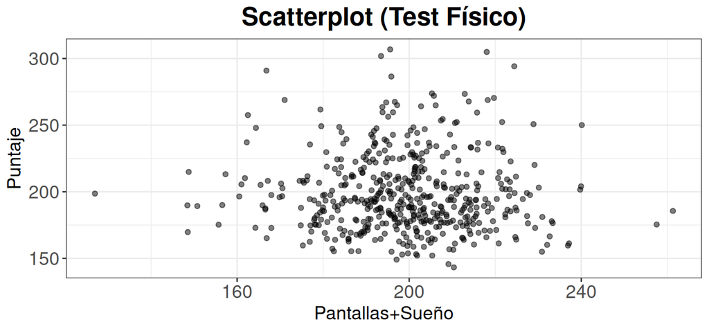

## Falsas relaciones lineales (Test Físico)

```r
round(cor(DatSim[IndF,3]-DatSim[IndF,4],DatSim[IndF,6]),3)
```

```
## [1] 0.028
```

[figure not shown]

## Falsas relaciones lineales (Test Físico)

```r
round(cor(-DatSim[IndF,3]+DatSim[IndF,4],DatSim[IndF,6]),3)
```

```
## [1] -0.028
```

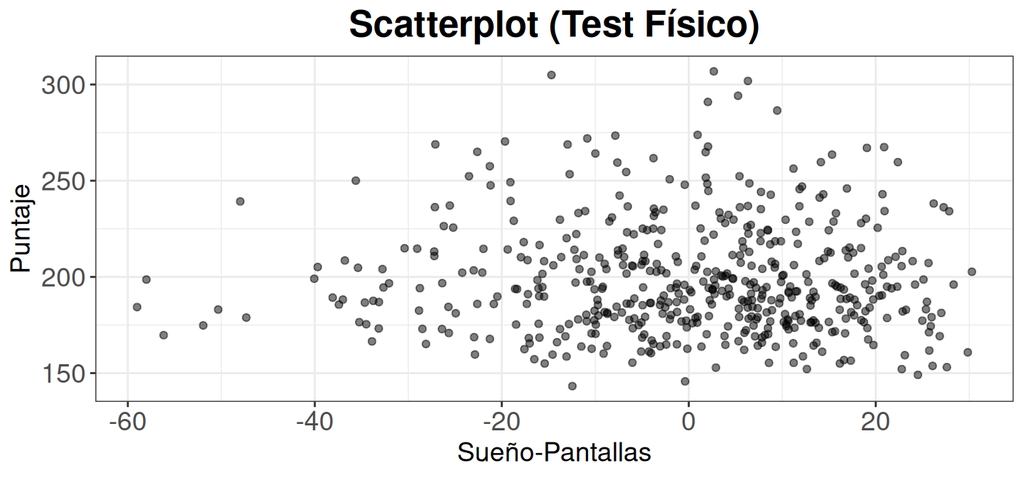

## Falsas relaciones lineales (Test Cognitivo)

```r
round(cor(DatSim[IndC,1]+DatSim[IndC,2],DatSim[IndC,6]),3)
```

```
## [1] -0.074
```

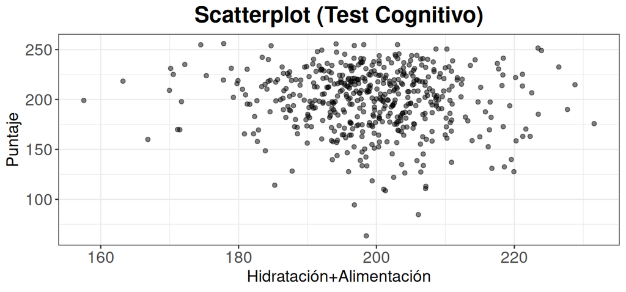

## Falsas relaciones lineales (Test Cognitivo)

```r
round(cor(DatSim[IndC,1]-DatSim[IndC,2],DatSim[IndC,6]),3)
```

```
## [1] 0.074
```

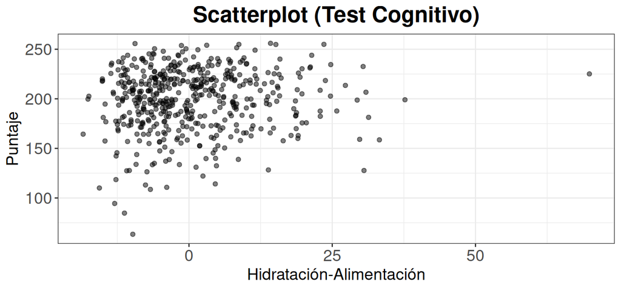

## Falsas relaciones lineales (Test Cognitivo)

```r
round(cor(-DatSim[IndC,1]+DatSim[IndC,2],DatSim[IndC,6]),3)
```

```
## [1] -0.074
```

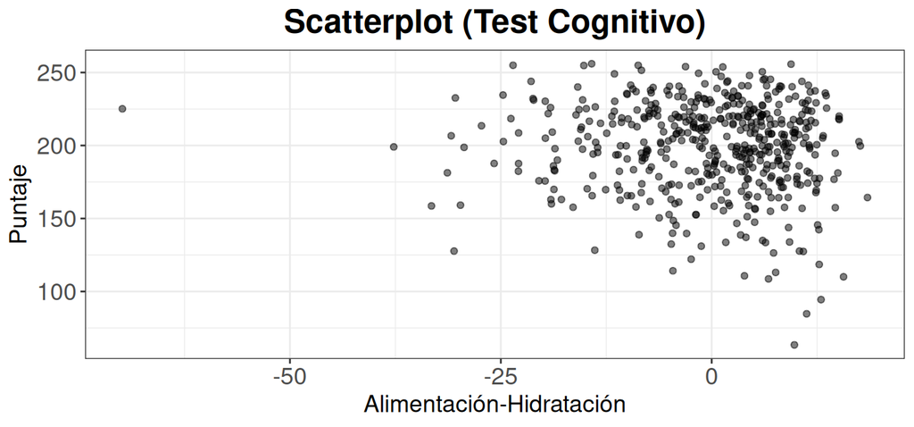

## Falsas relaciones lineales (Test Cognitivo)

```r
round(cor(DatSim[IndC,3]+DatSim[IndC,4],DatSim[IndC,6]),3)
```

```
## [1] 0.055
```

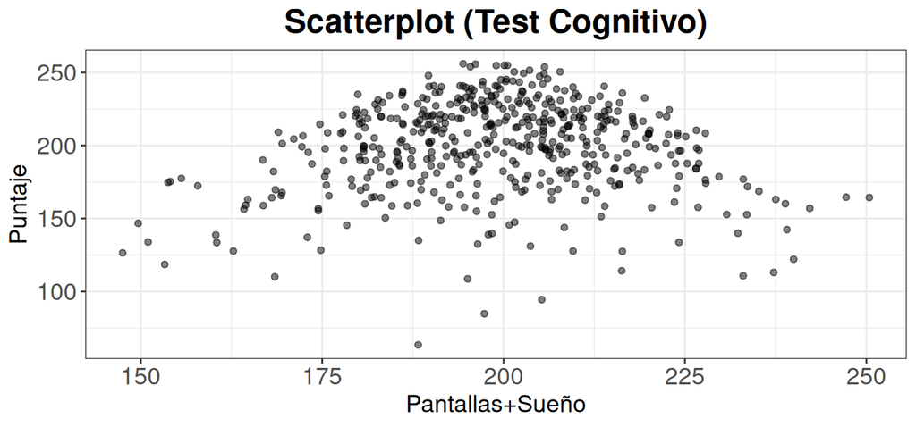

## Verdaderas relaciones lineales (Test Cognitivo)

```r
round(cor(DatSim[IndC,3]-DatSim[IndC,4],DatSim[IndC,6]),3)
```

```
## [1] -0.999
```

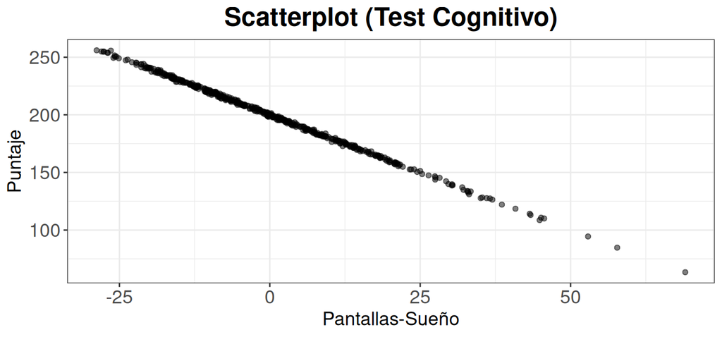

## Verdaderas relaciones lineales (Test Cognitivo)

```r
round(cor(-DatSim[IndC,3]+DatSim[IndC,4],DatSim[IndC,6]),3)
```

```
## [1] 0.999
```

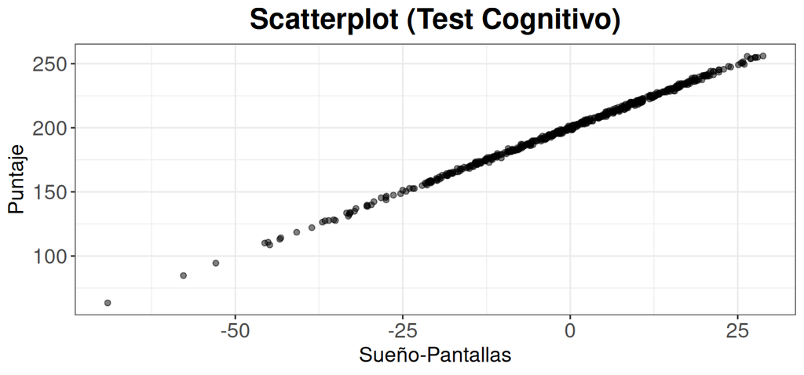

## Comentarios

- Notar que cuando elegimos las combinaciones correctas entre variables, encontramos relaciones casi lineales con la variable de puntaje.
- El problema es que si ensayamos con otra combinación, por más que sea similar, podemos no encontrar esta relación casi lineal. Por ejemplo, hemos visto que la siguiente relación lineal tiene correlación casi perfecta, pero si se cambia el coeficiente de alguna de las variables la relación pierde linealidad:

```r
round(cor(-DatSim[IndC,3]+DatSim[IndC,4],DatSim[IndC,6]),3)
```

```
## [1] 0.999
```

```r
round(cor(-5*DatSim[IndC,3]+DatSim[IndC,4],DatSim[IndC,6]),3)
```

```
## [1] 0.803
```

## Más comentarios

- Por otro lado, además de las combinaciones de coeficientes que hay que “probar” para encontrar una linealidad casi perfecta, si la base de datos tiene muchas variables, las combinaciones para testear se multiplican de una manera que no es posible realizar todas las visualizaciones necesarias.
- Por lo tanto, va a ser muy relevante encontrar procedimientos que busquen estas combinaciones en una base de datos grande.

## Distancia de Mahalanobis

La distancia de Mahalanobis es una distancia multivariada, que depende de un vector de medias \(\vec{\mu}\) y una matriz de covarianza \(\Sigma\): \[d_M(\vec{\mathbf{x}})=\sqrt{(\mathbf{x}-\vec{\mu})^T\times \Sigma^{-1} \times (\mathbf{x}-\vec{\mu})} \]

Básicamente, para cada vector de datos, la función devuelve cuánto se diferencia de un vector aleatorio con esa media y matriz de covarianza.

**Nota:** Por esto es importante que la matriz de covarianza sea semidefinida positiva para poder asegurar que tomamos una raíz cuadrada de un número positivo.

## Ejemplos

```
## Media: (0,0)
## Covarianza:
## (1 0)
## (0 1)
## Es decir, media en el origen y sin correlación
```

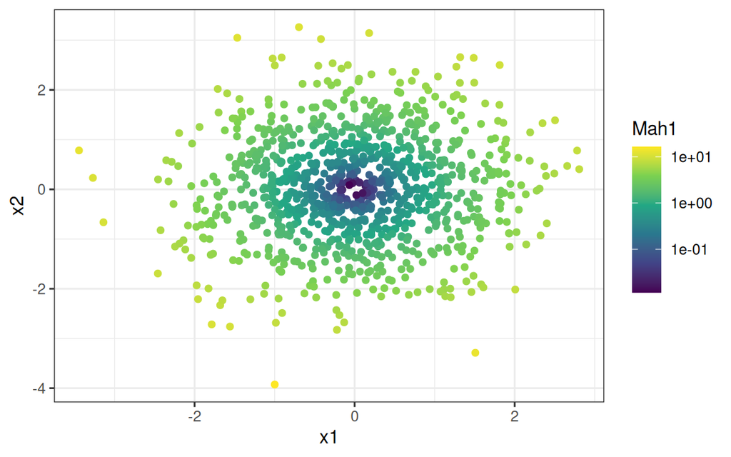

## Ejemplos

```
## Media: (1,1)
## Covarianza:
## (1 0)
## (0 1)
## Es decir, media en (1,1) y sin correlación
```

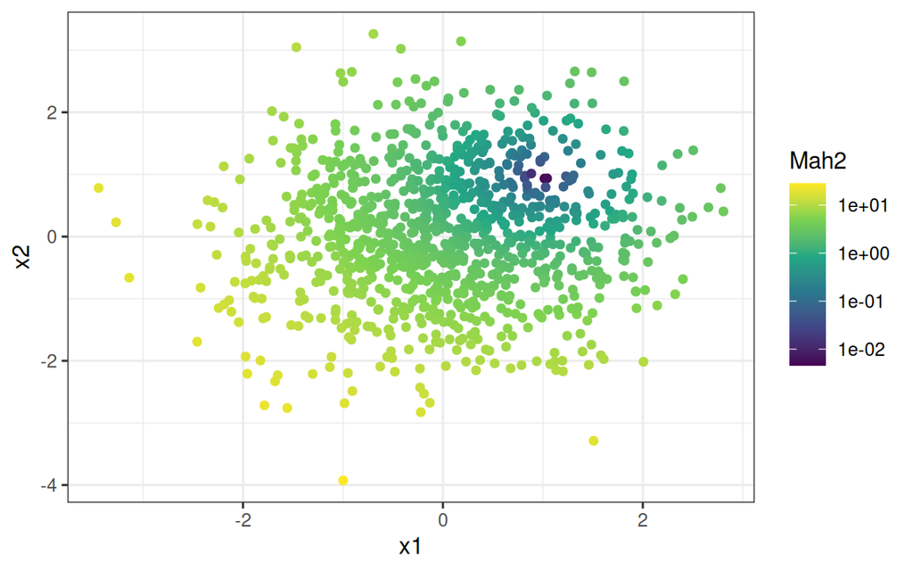

## Ejemplos

```
## Media: (0,0)
## Covarianza:
## (1 0.99)
## (0.99 1)
## Es decir, media en el origen y correlación positiva
```

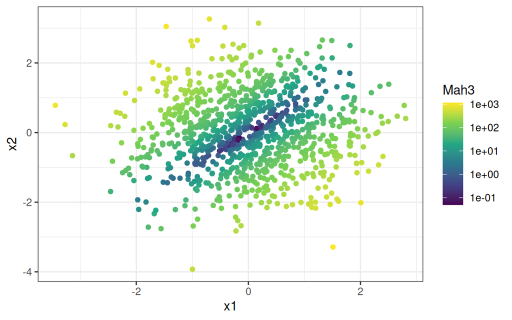

## Ejemplos

```
## Media: (0,0)
## Covarianza:
## (1 -0.99)
## (-0.99 1)
## Es decir, media en el origen y correlación negativa
```

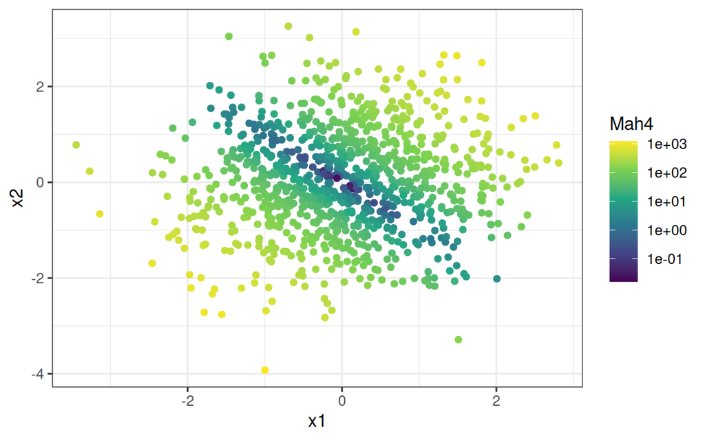

## Comentarios

Esta distancia es especialmente multivariada, ya que focaliza en la **combinación de variables**. Una muestra de eso es que hemos visto que la nube de puntos no tiene puntos aislados ni atípicos. Sin embargo, si se lo evalúa con una media y matriz de covarianza que no corresponden con los datos, esos datos empiezan a verse como “distantes” o atípicos.

Por ejemplo, cuando se mide la distancia usando una matriz de covarianza de correlación positiva, las combinaciones que dan valores altos en una variable y valores bajos en otra, empiezan a verse como “raros” porque aumenta la distancia, pero cuando se cambia la matriz de covarianza por una de covarianza negativa, se invierte la tendencia y esos mismos valores pasan a verse como “normales” o esperables”.

Por eso, esta distancia puede ser útil para detectar **combinaciones** que no corresponden a una cierta estructura, por más que sus valores no se vean como elevados ni llamen la atención.